主题 明暗

Generated by [Answer me with HTML](https://github.com/QingYunA/answer-me-with-html) 0.5.10 · 2026-10-30 23:26 · [★ Star on GitHub](https://github.com/QingYunA/answer-me-with-html)

# gptr v0.3 实验报告：从61秒与72秒展开

真实单细胞任务、五组对照，以及一对运行的完整甘特图

**报告版次**0.4**更新时间UTC**2026-10-30T05:57:35Z

A

## 摘要与研究背景

本文主案例：A1第2次运行与C1第3次运行

A1用时61.85秒，C1用时72.69秒，均正确完成任务。 本案例相差10.84秒，A1总时长低14.9%。 甘特图展示三轮请求与其中的执行步骤。

连续的数据分析通常包含检查、首次计算和条件修改。 前一轮已经加载的矩阵和质控结果，在下一轮仍然有用。 gptr将分析对象保留在R会话中。 普通coding agent则可以通过脚本和文件组织连续工作。 本实验比较这两种工作流在真实数据任务上的表现。

核心问题是：同一模型完成相同分析时，整条工作流花费多少时间？ 固定步骤实验进一步观察执行方式带来的成本。 真实轨迹回放则检查模型实际生成的R操作能否重复完成任务。

全文先交代实验方法，再展开主案例，最后呈现完整结果。 主案例恰好对应两组中位数，其他四次真实运行放入补充表。 本篇只分析已有v0.3记录，没有新增模型试验。

B

## 正式选用的数据集，以及要完成的分析任务

**正式选定的数据来自GSE236581公开单细胞数据集。**

这份数据记录了细胞中各个基因的表达计数。 公开完整数据集包含975275个细胞。 本轮从中选取100000个真实细胞，也就是10万个细胞。 每个选中细胞都保留全部36027个基因的数据。 五个实验组使用这一份相同的数据。

[figure not shown]

因此，975275表示公开完整队列的细胞数。 100000表示这次实际运行实验的细胞数。 本轮没有对完整队列测量性能，因为本机内存预检未通过。 选中的细胞及其表达计数均来自公开数据，没有模拟或复制。

**这份数据里具体存了什么？**

正式选用的10万细胞数据集

基因表达矩阵36027行基因 × 100000列细胞

细胞说明表每个细胞的编号、所属患者、组织和治疗时点

基因说明表每个基因的编号和名称

表达矩阵中的一个单元格，对应一个细胞中的一个基因。 其中的数字表示观测到的表达计数。 部分单元格为零，表示该位置没有检测到表达计数。

| 数据统计内容 | 数值 | 这个数字说明什么 |
| --- | --- | --- |
| 正式实验使用的细胞数 | 100,000 | 实验实际分析的细胞数量 |
| 基因数 | 36,027 | 每个细胞都保留的基因范围 |
| 有表达计数的单元格数 | 134,275,503 | 表达矩阵中计数大于零的位置数量 |
| 表达计数总和（UMI） | 377,073,775 | 将矩阵里的表达计数全部相加 |
| 覆盖的患者数 | 22 | 这些细胞来自22位患者 |
| 覆盖的原始样本数 | 169 | 这些细胞分布在169份原始样本中 |
| 后续分析分组数 | 168 | 按患者、组织和治疗时点组合后得到的组数 |

多个样本可以属于同一位患者。 同一患者、同一组织和同一时点的样本会合并分析。 因此，169份样本对应168个分析组。

**数据有多大，保存在哪里？**

上述矩阵和两份说明表一起保存为R数据文件 `input.rds`。 文件大小为1636075918字节，约1.64 GB。 矩阵采用稀疏格式，主要存储有计数的位置及其数值。 这能减少大量零值带来的存储负担。

这里的1.64 GB是数据文件大小。 程序运行时的内存占用另在F节报告。 本地数据文件位于 `data/gse236581-100000/input.rds`。

**拿到这份数据后，连续完成三轮分析。**

[figure not shown]

质控就是检查数据质量。 本任务为每个细胞计算表达计数总和，以及有表达的基因数。 随后使用这两个指标筛选细胞，再按组汇总表达量。

| 请求 | 具体做什么 | 产生什么结果 |
| --- | --- | --- |
| 1：检查与质控 | 核对编号和矩阵维度；计算每个细胞的两个质控指标 | qc.csv记录整体统计；cell-qc.csv记录10万个细胞的指标 |
| 2：首次汇总 | 保留表达计数总和≥1000、检测基因数≥500的细胞；汇总全部基因 | 保留99125个细胞，写出baseline.csv |
| 3：提高阈值 | 将两项条件提高到2000和1000；重新汇总全部基因 | 保留69684个细胞，写出revised.csv |

两次汇总均先计算全部基因，再提取八个标记基因。 每份表达结果包含168组×8个标记，共1344行。 每行报告细胞数、全基因总计数、标记计数及标准化表达量CPM。 空组也必须保留。

**原始下载文件怎样变成RDS？**

公开网站提供的是压缩矩阵和说明表，原文件不是RDS。

| 下载文件 | 保存的内容 |
| --- | --- |
| GSE236581_counts.mtx.gz | Matrix Market格式的原始表达计数矩阵 |
| GSE236581_barcodes.tsv.gz | 细胞编号 |
| GSE236581_features.tsv.gz | 基因编号与名称 |
| GSE236581_CRC-ICB_metadata.txt.gz | 细胞所属患者、组织和治疗时点 |

[figure not shown]

这一步预处理只做细胞选取、数据对齐和存储格式整理。 选中细胞的原始表达计数保持不变。 任务要求的质控指标和表达汇总没有预先算好。 RDS在正式计时前准备；各组加载RDS的时间仍计入实验。

**这些分析在什么环境中运行？**

| 实验条件 | 本轮采用的配置 |
| --- | --- |
| 模型 | GPT 6.1 SOL，显式指定gpt-6.1-sol |
| 模型入口 | 两个真实组均使用Codex CLI 0.165.0 |
| 思考强度 | 未显式覆盖；本机模型目录的默认值为low |
| 用户配置 | 实验命令忽略用户配置，不采用全局的思考强度设置 |
| 执行环境 | macOS arm64、32 GiB物理内存、R 4.5.1 |
| 主要数值依赖 | Matrix 1.7.3 |
| 执行安排 | 串行运行；A1/C1先后顺序交替 |

这里的low来自本次核对的Codex模型目录。 原实验清单只记录“模型默认”，未保存最终解析出的强度值。 模型配置核对记录保留了目录与会话依据。

查证：[公开数据集](https://www.ncbi.nlm.nih.gov/geo/query/acc.cgi?acc=GSE236581) · 正式数据集审计 · 任务定义 · 环境清单。

C

## 五组对照与计时方法

**真实组比较完整工作流，固定组比较相同计算的执行方式。**

[figure not shown]

| 组别 | 执行方式 | 是否真实模型 | 本组回答什么 |
| --- | --- | --- | --- |
| A1 | Codex经gptr桥接，使用常驻R会话 | 是 | gptr完整交互工作流的表现 |
| C1 | Codex自行组织脚本、命令和状态文件 | 是 | 普通coding agent完整工作流的表现 |
| A2 | fake回复驱动实际gptr循环 | 否 | 保留gptr机制后的重复执行成本 |
| C2 | 相同计算分三步，每步启动新R并恢复RDS | 否 | 分步进程与状态文件的成本 |
| C3 | 一个R进程连续执行相同三步 | 否 | 合并执行的批量基线 |

C1可以自主选择脚本和文件组织方式。 它没有被强制采用C2协议。 每次独立试验都使用新会话、新工作目录和同一份数据集。 同一次试验中的三个用户请求连续进行。

**计时覆盖完整响应过程。**

[figure not shown]

CSV写出后，最终文本回复和子进程退出仍在计时内。 正常权限处理与agent运行开销也包含在总时长中。 下载、数据准备、工作区复制和独立检查在计时外。 内存按20毫秒间隔采样进程树RSS。 系统缓存没有强制清空。

查证：计时及编排 · R执行器。

D

## 三轮请求统一视图：交互、工具执行与请求切换

**先区分用户请求和工具调用。**

用户请求是一轮完整分析要求，比如“检查数据并计算质控”。 工具调用是模型为完成这轮要求而执行的一次具体操作。 用户请求与工具调用不是一一对应的关系。 本案例的第一次用户请求包含两次R工具调用。

**整条工作流仍然是三次连续的用户请求。**

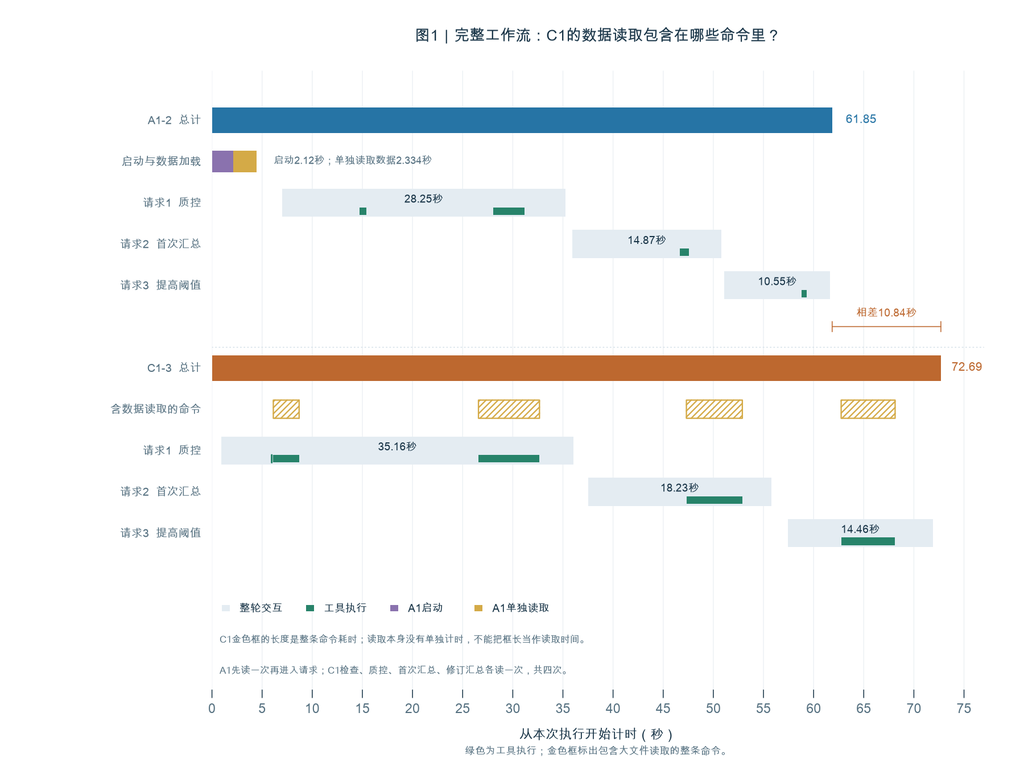

图1：按请求实际起止事件绘制的完整工作流甘特图

放大完整甘特图 · 矢量图

本版按可观察的请求开始和最终回复事件画浅色条。 绿色是每轮内部的工具执行，条之间留出请求切换时间。 三轮由runner顺序提交，没有加入人工阅读或等待时间。

| 环节 | A1-2（秒） | C1-3（秒） |
| --- | --- | --- |
| 首次请求之前的准备 | 6.996 | 0.915 |
| 请求1完整交互 | 28.248 | 35.161 |
| 请求1结束到请求2进入 | 0.688 | 1.460 |
| 请求2完整交互 | 14.869 | 18.230 |
| 请求2结束到请求3进入 | 0.302 | 1.661 |
| 请求3完整交互 | 10.553 | 14.464 |
| 最终收尾 | 0.195 | 0.802 |
| **总时长** | **61.851** | **72.692** |

A1首轮前的准备包含R启动、数据加载和gptr会话准备。 C1的R启动与读取则包含在各轮外部命令中。

**把A1的三轮请求放在一张图里，连续查看所有工具调用。**

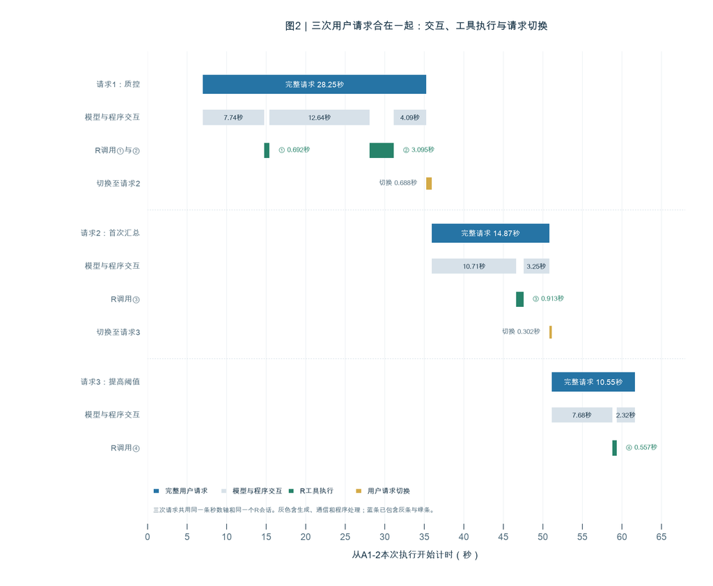

图2：A1-2三轮请求统一时间轴，展开全部交互、四次R调用与两次请求切换

放大三轮请求统一视图 · 矢量图

图中的三组行共用同一条秒数轴。 每组都按“完整请求、模型与程序交互、R工具执行”排列。 蓝条是整轮总时长，已经包含灰色交互区间和绿色R执行区间。 两次黄色切换区间连接相邻用户请求。

**四次R调用各自完成什么？**

| 所属请求 | 图中R调用 | 具体解决的问题 | 起止时刻（秒） | 耗时（秒） |
| --- | --- | --- | --- | --- |
| 请求1 | ① 查看结构 | 查看矩阵维度、说明表字段、编号与示例，供模型组织后续代码 | 14.734—15.426 | 0.692 |
| 请求1 | ② 计算质控 | 校验编号与数据；计算每细胞UMI和检测基因数；建立分组并导出两份QC文件 | 28.061—31.156 | 3.095 |
| 请求2 | ③ 首次汇总 | 复用QC与分组；应用1000和500阈值；汇总全部基因，再提取标记并导出baseline.csv | 46.641—47.554 | 0.913 |
| 请求3 | ④ 阈值修订 | 复用已有对象；将阈值提高到2000和1000；重新汇总并导出revised.csv | 58.781—59.338 | 0.557 |

请求1需要先了解结构，再执行完整质控，因此有两次R调用。 请求2和请求3使用已经保留的对象，各完成一次R调用。 四次调用始终使用同一个R会话。

**用相同口径对照三轮内部耗时。**

| 用户请求 | 首次工具前 | R执行合计 | 工具之间 | 最后工具后 | 总时长（秒） |
| --- | --- | --- | --- | --- | --- |
| 请求1 | 7.738 | 3.787 | 12.635 | 4.088 | **28.248** |
| 请求2 | 10.709 | 0.913 | 0.000 | 3.247 | **14.869** |
| 请求3 | 7.678 | 0.557 | 0.000 | 2.318 | **10.553** |

表内单位均为秒。 请求2和请求3只有一次工具调用，因此“工具之间”为零。 灰色时间包含模型生成、通信、调度和结果处理。 它们没有被单独测成纯thinking时间。

**三次用户请求如何衔接？**

所有时刻均从A1-2整次运行开始计算。

| 用户请求 | 进入gptr（秒） | 最终回复结束（秒） | 到下一请求的切换（秒） |
| --- | --- | --- | --- |
| 请求1 | 6.996 | 35.244 | 0.688 |
| 请求2 | 35.932 | 50.801 | 0.302 |
| 请求3 | 51.103 | 61.656 | 任务完成 |

A1以用户消息进入和最终助手消息结束划分请求。 C1使用CLI的 `turn.started` 和 `turn.completed`。 下一次工具开始不等于下一次用户请求开始。 例如，请求2在35.932秒进入，R调用③到46.641秒才开始。 三轮由runner顺序提交，中间没有人工停顿。

本版合并了三轮内部视图，总时长仍为61.85和72.69秒。 逐次请求与工具明细保留全部六次真实运行的拆分。

E

## 大文件读取与工具执行：10.84秒的差额落在哪里

**这份约1.64 GB的大文件，读取一次要多久？**

正式A1-2对 `readRDS()` 单独计时，结果为 **2.334秒**。 它发生在用户请求1之前，已经计入61.85秒总时长。 之后的质控与两次汇总直接复用会话对象。 因此，质控R调用的3.095秒没有再次包含大文件读取。

**C1也读取数据，只是读时融入了各条R命令。**

| 运行环节 | A1-2 | C1-3 |
| --- | --- | --- |
| 请求之前 | 一次读取，独立计时2.334秒 | CLI启动；尚未进入R分析 |
| 请求1：结构检查 | 使用已加载对象 | R1读取一次；包含在2.572秒命令中 |
| 请求1：计算质控 | 继续使用同一对象 | R2再读一次；包含在6.084秒命令中 |
| 请求2：首次汇总 | 复用数据与QC | R3再读一次；包含在5.578秒命令中 |
| 请求3：提高阈值 | 复用数据与QC | R4再读一次；包含在5.380秒命令中 |
| **原始大文件读取次数** | **1次** | **4次** |

图1新增金色框，标出C1包含大文件读取的四条命令。 框长是整条命令的时长，不能当作读取本身的时长。 原C1没有为 `readRDS()` 单独打点，所以每次独立读时未记录。 这些读取都已包含在72.69秒总时长中。

**补充测量：同一文件在五个新R进程中分别读取一次。**

[figure not shown]

**数据**

| 补测1 | 2.451s |
| --- | --- |
| 补测2 | 2.587s |
| 补测3 | 2.28s |
| 补测4 | 2s |
| 补测5 | 1.903s |

五次补测中位数为 **2.280秒**。 耗时范围为 **1.903—2.587秒**。 只计 `readRDS()` 恢复R对象的过程，R进程启动不在该计时内。 这说明当前条件下，一次读取大致需要两秒左右。

补测在报告修订时执行，与原66次正式执行分开保存。 系统缓存未清空，测前也读取过文件以核对哈希。 这些数值不能追溯替代C1当时的四次独立读时。 读取时间也包含对象恢复，不能当作纯磁盘传输时间。

大文件读取优化应先关注是否需要反复恢复同一份数据。 本案例A1读一次，C1读四次，重复读取的位置已可直接查看。

查证：五次读取补测 · 方法、文件哈希和环境 · 补测R脚本。

**A1四次R调用复用一个会话；C1启动四个R进程。**

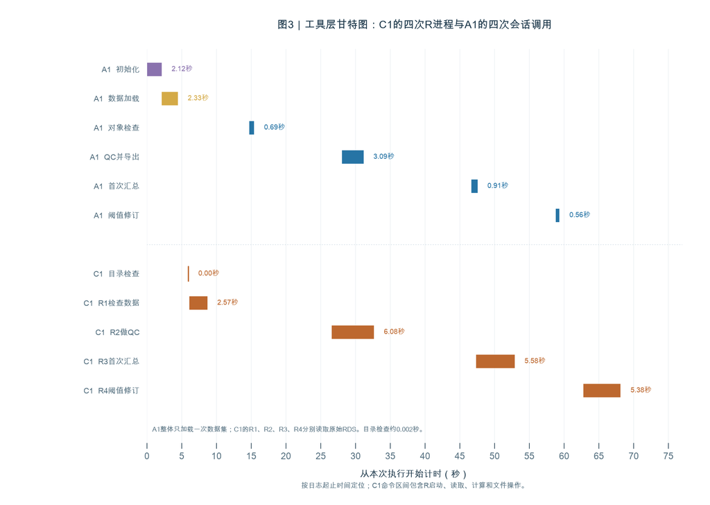

图3：对象检查、质控、首次汇总和阈值修订的工具甘特图

放大查看工具甘特图 · 矢量图

本案例C1先用R1读取并检查数据集。 随后R2做质控，R3做首次汇总，R4运行修订脚本。 四个R进程分别读取原始RDS。 A1在开始时加载一次，后面的R调用直接使用已有对象。

| 操作 | A1-2（秒） | C1-3（秒） |
| --- | --- | --- |
| A1启动R、加载gptr并完成准备 | 2.118 | 包含在命令中 |
| A1预先加载数据集 | 2.334 | 包含在命令中 |
| 目录检查 | — | 0.002 |
| 对象结构检查 | 0.692 | 2.572 |
| 质控计算与产物导出 | 3.095 | 6.084 |
| 首次全基因汇总与导出 | 0.913 | 5.578 |
| 阈值修订、重新汇总与导出 | 0.557 | 5.380 |

C1每条R命令还包含R启动、包加载和文件读写。 其中部分命令也包含脚本写入或修改。 这些时间没有继续拆成单独的数值。 因此，表中比较的是各自整段执行区间。

**把互不重叠的执行相关区间归并，再看剩余时间。**

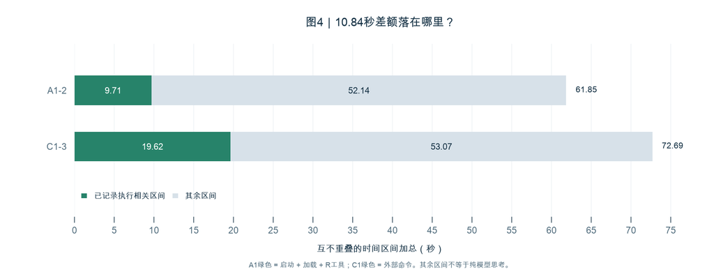

图4：执行相关时间与其余时间的加总比较

| 归并口径 | A1-2（秒） | C1-3（秒） | C1减A1（秒） |
| --- | --- | --- | --- |
| 已记录执行相关区间 | 9.709 | 19.617 | +9.908 |
| 其余区间 | 52.142 | 53.075 | +0.933 |
| **合计** | **61.851** | **72.692** | **+10.841** |

A1第一行等于启动、预载和四次R工具区间之和。 C1第一行等于五条外部命令区间之和。 这两次运行的主要差额落在这些执行相关区间。 从过程看，C1重复启动R、读取数据集并经由文件恢复状态。 这为观察到的差异提供了具体解释。

如何读这个拆分

其余52.14秒与53.07秒是总时长减去执行相关区间。 它们包含模型交互、代码生成、通信、回复和运行开销。 现有记录不能把它们单独称为“模型思考时间”。

查证：A1-2原始轨迹 · C1-3原始轨迹 · 本篇拆分明细。

F

## 完整结果：真实运行、固定步骤与内存

**所有真实运行都保留，主案例之外还有四次观测。**

[figure not shown]

**数据**

| A1-1 | 61.931s |
| --- | --- |
| A1-2 | 61.851s |
| A1-3 | 58.649s |
| C1-1 | 70.191s |
| C1-2 | 94.573s |
| C1-3 | 72.692s |

A1三次为58.65—61.93秒，C1三次为70.19—94.57秒。 C1第2次较慢，所以也需要呈现每次运行。 真实组各三次，不能用回放次数扩大真实模型样本数。

| 组别 / 来源 | 正确 / 次数 | 中位数（秒） | 范围（秒） | RSS中位数（MiB） |
| --- | --- | --- | --- | --- |
| A1 / live | 3/3 | 61.851 | 58.649—61.931 | 3731.9 |
| C1 / live | 3/3 | 72.692 | 70.191—94.573 | 2969.2 |
| A2 / canonical | 10/10 | 11.991 | 11.750—13.264 | 3113.2 |
| C2 / canonical | 10/10 | 10.358 | 10.245—10.644 | 2768.4 |
| C3 / canonical | 10/10 | 5.116 | 4.960—5.310 | 2868.9 |

**固定步骤中，C3最快，C2其次，A2耗时最长。**

[figure not shown]

**数据**

| A2固定gptr步骤 | 11.991s |
| --- | --- |
| C2分步RDS | 10.358s |
| C3单进程R | 5.116s |

这三组执行相同的预设R计算。 结果提示，批量组织任务可进一步降低总执行成本。 常驻会话能复用对象，但gptr循环也有自己的开销。 因此，真实A1较快与固定A2较慢可以同时成立。

**真实组的速度差异伴随内存差异。**

**数据**

| A1真实gptr | 3731.9MiB |
| --- | --- |
| C1真实Codex | 2969.2MiB |

上图使用各组三次采样峰值的中位数。 主案例本身分别为4050.8和2969.2 MiB。 RSS是进程树采样和，不能当作精确独占内存。

查证：66次正式记录 · 汇总统计。

G

## 正确性、真实轨迹回放与结果边界

**66次正式执行全部通过独立产物检查。**

| 实验部分 | 数量 | 作用 |
| --- | --- | --- |
| A1与C1真实运行 | 2组×3次＝6 | 观察完整模型工作流 |
| A2、C2、C3固定步骤 | 3组×10次＝30 | 观察相同计算的执行波动 |
| 三条A1真实轨迹进入A2 | 3条×10次＝30 | 检查实际R操作的可重复执行 |

独立检查器核对标识、QC、筛选结果、组别和计数。 整数要求完全一致，CPM容差为 `1e-6`。 过程审计也确认六次真实运行先聚合全部基因，再提取标记。 本案例两次独立检查均返回 `ok: true`。

[figure not shown]

| 回放来源 | 正确 / 次数 | 中位数（秒） | 范围（秒） |
| --- | --- | --- | --- |
| A1轨迹1 → A2 | 10/10 | 13.334 | 13.023—14.111 |
| A1轨迹2 → A2 | 10/10 | 13.081 | 13.002—13.180 |
| A1轨迹3 → A2 | 10/10 | 12.528 | 12.372—13.018 |

真实轨迹回放保留模型实际选择的检查和R操作。 它与预设标准步骤分开汇总。 两条轨迹曾因验证器缺少原生辅助函数而被拒绝转换。 补齐验证环境后，保留原代码并补跑；原拒绝记录仍可查。 这属于回放环境修复，未改写真实组的观测值。

本轮可以说明这个任务上的完整工作流表现。 还不能据此判断所有任务或模型上的速度差异。 1万细胞预检与开发验证没有混入66次正式统计。

查证：主案例A1正确性 · C1正确性 · 完整过程审计 · 回放索引。

H

## 补充表、版本与查证入口

**补充表：六次真实运行的请求时长。**

| 运行 | 总计（秒） | 质控请求 | 首次汇总请求 | 修订请求 | 请求外时间 |
| --- | --- | --- | --- | --- | --- |
| A1-1 | 61.931 | 27.929 | 12.356 | 13.472 | 8.174 |
| A1-2 | 61.851 | 28.248 | 14.869 | 10.553 | 8.181 |
| A1-3 | 58.649 | 26.127 | 12.867 | 11.888 | 7.767 |
| C1-1 | 70.191 | 33.967 | 18.662 | 11.943 | 5.620 |
| C1-2 | 94.573 | 49.938 | 20.790 | 18.376 | 5.469 |
| C1-3 | 72.692 | 35.161 | 18.230 | 14.464 | 4.837 |

每行三个请求时长加“请求外时间”等于总计。 请求外时间包含首轮前准备、两次请求切换和最终收尾。 表中数值显示到毫秒，加总可能有四舍五入差异。 本版细化了内部区间的边界，没有改动正式实验总时长。

**本篇图表怎样从日志得到？**

A1以用户消息进入和最终助手消息结束划分每次请求。 C1以 `turn.started` 和 `turn.completed` 划分每次请求。 前版按完成事件分配的时段保留在拆分JSON中供核对。

工具区间从对应的开始和结束事件计算。 A1工具轨迹加上启动与加载时间后，放到总时长轴上。 墙钟记录核对该平移，误差小于5毫秒。 请求前准备、请求切换和收尾都保留在总时长内。

这些是已有日志的事后拆分，足够说明本案例的工作过程。 工具区间仍包含接口开销，并非纯R数值运算时间。 模型记录中的provider总时长也可能包含工具执行。 因此，本篇没有把provider时间和工具时间再次相加。

| 要核对的问题 | 阅读入口 | 更细记录 |
| --- | --- | --- |
| 大文件读取用了多久？ | 五次读取补测 | 补测方法与环境；原A1读时见主案例结果 |
| 默认思考强度如何核对？ | 模型目录与历史会话摘录 | 仅保存模型设置字段，不复制完整会话内容 |
| 61.85与72.69来自哪里？ | 本篇阶段CSV | 拆分规则及源文件SHA256 |
| 主案例的每个步骤是什么？ | A1-2结果、C1-3结果 | 两个目录中的trace.jsonl及原始日志 |
| 正式数据集如何选取并验证？ | 数据清单 | 准备程序、数据集审计 |
| 任务和答案如何定义？ | 任务代码 | 独立检查器 |
| 五组和采样如何实现？ | 运行说明 | Python编排、R执行器 |
| 所有正式结果在哪？ | 正式66次CSV | 主实验目录与英文报告 |

本篇报告版次为0.4，更新时间为 `2026-10-30T05:57:35Z`。 实验主记录仍冻结于0.3.0，补充回放冻结于0.3.1。 计划当前为0.3.2，版本日期见 plan.md。 原先的实验设计详解继续保留。 本篇增加甘特图和阶段拆分，后续可围绕这些图表逐步修订。